# Making Maps with ggplot2, maps, and mapproj

Daniel Kaplan

May 9, 2014

Some notes on how to make world/country/county maps.

Goal: Produce a small set of functions that we can use to streamline map-making from data.

You need the shapefiles from `maps` and the projections from `mapproj`, as well as `ggplot2` to do the drawing.

```r
library(dplyr) #always!
library(maps)
library(mapproj)
library(ggplot2)
```

### 1. Choose a Region

We can use this directly.

```r
shapes <- map_data('world')
```

### 2. Get data

Get data for the units of the map, e.g. countries. These are identified under `region` in `shapes`.

### 3. Reconcile the codes in your map to those in the shapes file.

Write a function that compares the shape info and data to point out any missing or mismatched ones. I think there is already functionality in the `rworldmap` package to do this. Use that if it will work.

### 4. Merge the reconciled data with the shapefile.

I’m thinking that it might be good to provide one function that takes the shapefile and the reconciled data, merges them, calls `ggplot()` and returns a ggplot object which has no layers.

In writing the function, use syntax like this

```r
myMap <- makeMap(shapefile,datafile,varname)
```

> For the next items, I’m going to make a bogus dataset in the right form. Since the `shapes$regions` are `chars`, I need to make sure that the conversion in `myData` is correct.

```r
countryNames <- unique(shapes$region)
myData <- data.frame( val=runif(length(countryNames)),
                      region=countryNames,stringsAsFactors=FALSE )
shapesAndData <- inner_join(shapes,myData)
```

> Now use `shapesAndData` for the plotting.

The basic `ggplot2` syntax is

```r
myMap <- ggplot(shapesAndData, aes(x=long,y=lat,group=group,order=order))
```

Add the layers. Two basic types: outlines and fills.

Outlines:

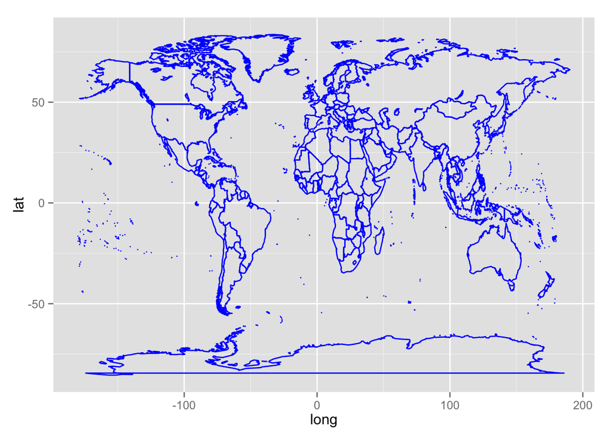

```r
myMap + geom_polygon(color='blue',fill=NA)
```

Fills:

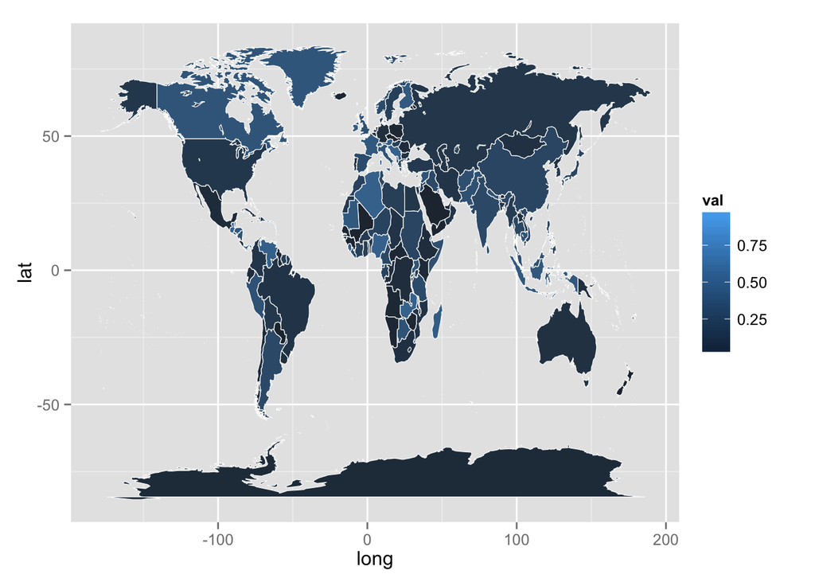

```r
myMap + geom_polygon(aes(fill=val)) + geom_polygon(color='white',alpha=0.5,size=0.2)
```

`size` controls the width of the boundaries. `alpha` sets the translucence.

### Use the with the bells and whistles of `ggplot2`.

Add in more features. Provide a list of examples

Important one: `coord_map(project='aitoff')` or `'mercator'` or `'polyconic'`. See the `mapproj` package for more info.

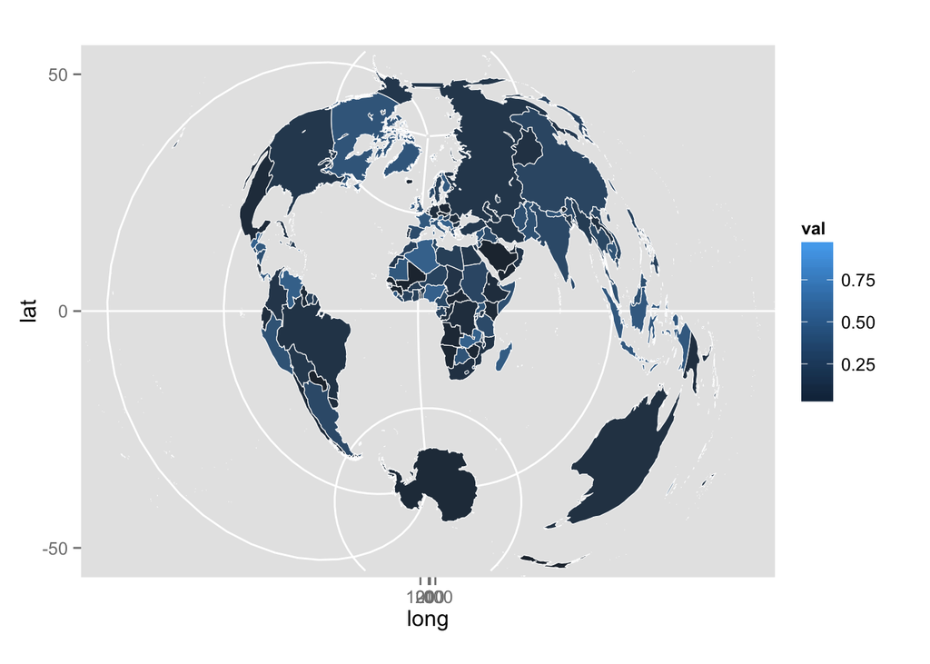

```r
myMap + geom_polygon(aes(fill=val)) + geom_polygon(color='white',alpha=0.5,size=0.2) +
  coord_map(project='polyconic')  # <---- the bell and whistle
```

- The pallete? Or make this an argument to `makeMap()`
- Suppress axis ticks or box around plot.

### Miscellaneous

- There seem to be some points from USSR that are given in longitude west (negative) rather than longitude east (positive). It might be a good exercise to fix them.
- More generally, the world map is out of date. Some suggestions for fixing this are [here](http://stackoverflow.com/questions/15757793/updated-world-map-for-r-maps-package). But there is a whole literature here (see `maptools` package) and we don’t want to get too deeply involved. > Is there a way to convert `maptools::wrld_simpl` into a format that can be used by `map_data()`?